# HW5_Applied_Statistics

Daria Ganaeva

31 05 2024

Upload the libraries:

```r
library(ade4)
library(vegan)
library(car)
```

Upload the data:

```r
data('doubs', package = 'ade4')
```

Distinguish the data:

```r
fish <- doubs$fish
envi <- doubs$env
coord <- doubs$xy
```

Explore the data:

output first lines:

```r
head(fish, 3)
```

```
##   Cogo Satr Phph Neba Thth Teso Chna Chto Lele Lece Baba Spbi Gogo Eslu Pefl
## 1    0    3    0    0    0    0    0    0    0    0    0    0    0    0    0
## 2    0    5    4    3    0    0    0    0    0    0    0    0    0    0    0
## 3    0    5    5    5    0    0    0    0    0    0    0    0    0    1    0
##   Rham Legi Scer Cyca Titi Abbr Icme Acce Ruru Blbj Alal Anan
## 1    0    0    0    0    0    0    0    0    0    0    0    0
## 2    0    0    0    0    0    0    0    0    0    0    0    0
## 3    0    0    0    0    0    0    0    0    0    0    0    0
```

```r
head(envi, 3)
```

```
##   dfs alt   slo flo pH har pho nit amm oxy bdo
## 1   3 934 6.176  84 79  45   1  20   0 122  27
## 2  22 932 3.434 100 80  40   2  20  10 103  19
## 3 102 914 3.638 180 83  52   5  22   5 105  35
```

```r
head(coord, 3)
```

```
##     x  y
## 1  88  7
## 2  94 14
## 3 102 18
```

```r
envi_coord <- cbind(envi, coord)
```

doubs$env contains the following variables:

dfs - distance from the source (km * 10),

alt - altitude (m), slo (log(x + 1) where x is the slope (per mil * 100),

flo - minimum average stream flow (m3/s * 100),

pH (* 10), har - total hardness of water (mg/l of Calcium),

pho - phosphates (mg/l * 100),

nit - nitrates (mg/l * 100),

amm - ammonia nitrogen (mg/l * 100),

oxy - dissolved oxygen (mg/l * 10),

bdo - biological demand for oxygen (mg/l * 10).

Check the distribution:

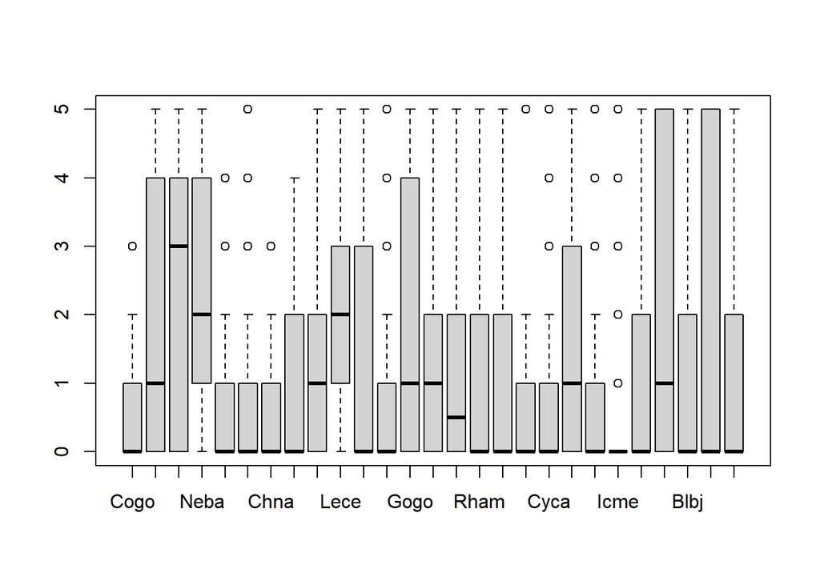

```r
boxplot(fish)
```

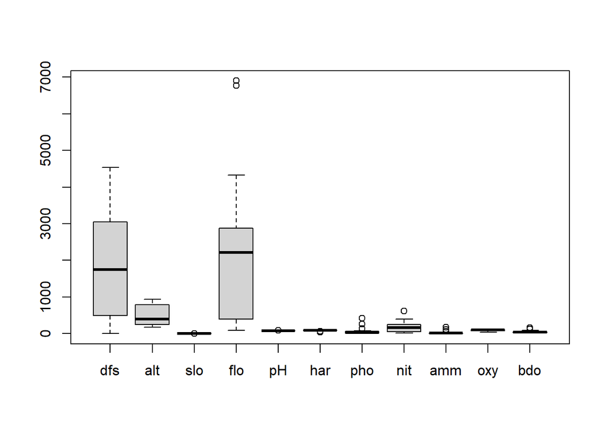

```r
boxplot(envi)
```

```r
summary(fish)
```

```
##       Cogo           Satr           Phph            Neba            Thth
##  Min.   :0.00   Min.   :0.00   Min.   :0.000   Min.   :0.000   Min.   :0.00
##  1st Qu.:0.00   1st Qu.:0.00   1st Qu.:0.000   1st Qu.:1.000   1st Qu.:0.00
##  Median :0.00   Median :1.00   Median :3.000   Median :2.000   Median :0.00
##  Mean   :0.50   Mean   :1.90   Mean   :2.267   Mean   :2.433   Mean   :0.50
##  3rd Qu.:0.75   3rd Qu.:3.75   3rd Qu.:4.000   3rd Qu.:4.000   3rd Qu.:0.75
##  Max.   :3.00   Max.   :5.00   Max.   :5.000   Max.   :5.000   Max.   :4.00
##       Teso             Chna          Chto             Lele
##  Min.   :0.0000   Min.   :0.0   Min.   :0.0000   Min.   :0.000
##  1st Qu.:0.0000   1st Qu.:0.0   1st Qu.:0.0000   1st Qu.:0.000
##  Median :0.0000   Median :0.0   Median :0.0000   Median :1.000
##  Mean   :0.6333   Mean   :0.6   Mean   :0.8667   Mean   :1.433
##  3rd Qu.:0.7500   3rd Qu.:1.0   3rd Qu.:2.0000   3rd Qu.:2.000
##  Max.   :5.0000   Max.   :3.0   Max.   :4.0000   Max.   :5.000
##       Lece            Baba            Spbi          Gogo            Eslu
##  Min.   :0.000   Min.   :0.000   Min.   :0.0   Min.   :0.000   Min.   :0.000
##  1st Qu.:1.000   1st Qu.:0.000   1st Qu.:0.0   1st Qu.:0.000   1st Qu.:0.000
##  Median :2.000   Median :0.000   Median :0.0   Median :1.000   Median :1.000
##  Mean   :1.867   Mean   :1.433   Mean   :0.9   Mean   :1.833   Mean   :1.333
##  3rd Qu.:3.000   3rd Qu.:3.000   3rd Qu.:1.0   3rd Qu.:3.750   3rd Qu.:2.000
##  Max.   :5.000   Max.   :5.000   Max.   :5.0   Max.   :5.000   Max.   :5.000
##       Pefl          Rham          Legi             Scer          Cyca
##  Min.   :0.0   Min.   :0.0   Min.   :0.0000   Min.   :0.0   Min.   :0.0000
##  1st Qu.:0.0   1st Qu.:0.0   1st Qu.:0.0000   1st Qu.:0.0   1st Qu.:0.0000
##  Median :0.5   Median :0.0   Median :0.0000   Median :0.0   Median :0.0000
##  Mean   :1.2   Mean   :1.1   Mean   :0.9667   Mean   :0.7   Mean   :0.8333
##  3rd Qu.:2.0   3rd Qu.:2.0   3rd Qu.:1.7500   3rd Qu.:1.0   3rd Qu.:1.0000
##  Max.   :5.0   Max.   :5.0   Max.   :5.0000   Max.   :5.0   Max.   :5.0000
##       Titi          Abbr             Icme          Acce            Ruru
##  Min.   :0.0   Min.   :0.0000   Min.   :0.0   Min.   :0.000   Min.   :0.0
##  1st Qu.:0.0   1st Qu.:0.0000   1st Qu.:0.0   1st Qu.:0.000   1st Qu.:0.0
##  Median :1.0   Median :0.0000   Median :0.0   Median :0.000   Median :1.0
##  Mean   :1.5   Mean   :0.8667   Mean   :0.6   Mean   :1.267   Mean   :2.1
##  3rd Qu.:3.0   3rd Qu.:1.0000   3rd Qu.:0.0   3rd Qu.:2.000   3rd Qu.:5.0
##  Max.   :5.0   Max.   :5.0000   Max.   :5.0   Max.   :5.000   Max.   :5.0
##       Blbj            Alal          Anan
##  Min.   :0.000   Min.   :0.0   Min.   :0.00
##  1st Qu.:0.000   1st Qu.:0.0   1st Qu.:0.00
##  Median :0.000   Median :0.0   Median :0.00
##  Mean   :1.033   Mean   :1.9   Mean   :0.90
##  3rd Qu.:1.750   3rd Qu.:5.0   3rd Qu.:1.75
##  Max.   :5.000   Max.   :5.0   Max.   :5.00
```

The data looks okay, we can proceed without scaling.

Check for missing values:

```r
sum(is.na(fish))
```

```
## [1] 0
```

```r
sum(is.na(envi))
```

```
## [1] 0
```

```r
sum(is.na(coord))
```

```
## [1] 0
```

No missing value is present in the dataset.

Check linearity of variables relationship:

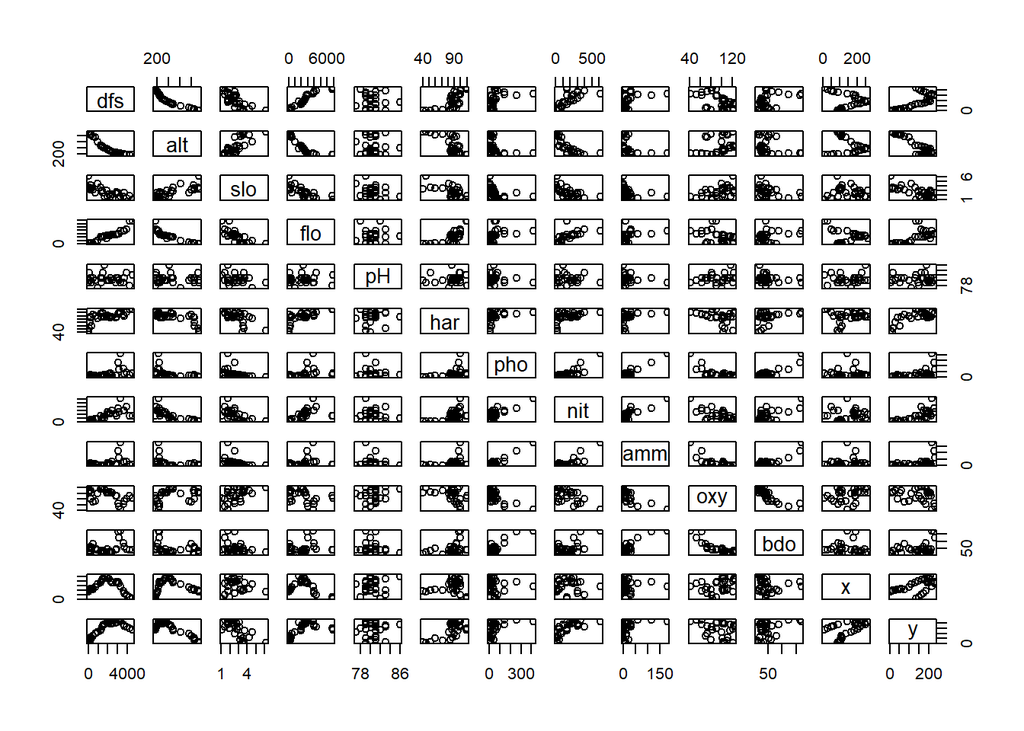

```r
pairs(envi_coord)
```

RDA:

```r
vif(lm(fish$Satr ~ ., data = envi_coord))
```

```
##        dfs        alt        slo        flo         pH        har        pho
## 381.288793 246.573567   5.702796  69.476233   1.873105   6.324687  26.513991
##        nit        amm        oxy        bdo          x          y
##  21.490514  34.735535  17.636400  18.212188  70.162064 165.450983
```

Let’s remove altitude and flow env factors as they have high vif and possibly correlate with slo variable:

```r
vif(lm(fish$Satr ~ . -alt -flo, data = envi_coord))
```

```
##        dfs        slo         pH        har        pho        nit        amm
##  61.783675   4.360078   1.400464   2.950420  22.711462  13.366624  30.795389
##        oxy        bdo          x          y
##   9.987960  17.262554  52.379288 119.730939
```

Now vif factors look much better.

RDA analysis:

```r
rda <- rda(fish ~ dfs + slo + pH + har + pho + nit + amm + oxy + bdo, data = envi_coord)
summary(rda)
```

```
##
## Call:
## rda(formula = fish ~ dfs + slo + pH + har + pho + nit + amm +      oxy + bdo, data = envi_coord)
##
## Partitioning of variance:
##               Inertia Proportion
## Total           68.36     1.0000
## Constrained     50.23     0.7349
## Unconstrained   18.12     0.2651
##
## Eigenvalues, and their contribution to the variance
##
## Importance of components:
##                          RDA1    RDA2   RDA3   RDA4     RDA5     RDA6     RDA7
## Eigenvalue            39.4076 6.14478 1.8800 1.2512 0.582974 0.470665 0.293897
## Proportion Explained   0.5765 0.08989 0.0275 0.0183 0.008528 0.006885 0.004299
## Cumulative Proportion  0.5765 0.66640 0.6939 0.7122 0.720730 0.727616 0.731915
##                           RDA8     RDA9     PC1     PC2     PC3     PC4     PC5
## Eigenvalue            0.119512 0.083259 6.24914 3.41926 1.93733 1.47386 1.18587
## Proportion Explained  0.001748 0.001218 0.09142 0.05002 0.02834 0.02156 0.01735
## Cumulative Proportion 0.733664 0.734882 0.82630 0.87632 0.90466 0.92623 0.94357
##                           PC6     PC7      PC8      PC9    PC10     PC11   PC12
## Eigenvalue            0.84671 0.73891 0.483036 0.414594 0.35273 0.294387 0.2119
## Proportion Explained  0.01239 0.01081 0.007066 0.006065 0.00516 0.004307 0.0031
## Cumulative Proportion 0.95596 0.96677 0.973837 0.979903 0.98506 0.989369 0.9925
##                           PC13    PC14     PC15      PC16      PC17     PC18
## Eigenvalue            0.178079 0.13258 0.086279 0.0536099 0.0339678 0.017978
## Proportion Explained  0.002605 0.00194 0.001262 0.0007843 0.0004969 0.000263
## Cumulative Proportion 0.995075 0.99701 0.998276 0.9990605 0.9995575 0.999820
##                            PC19      PC20
## Eigenvalue            0.0112981 9.747e-04
## Proportion Explained  0.0001653 1.426e-05
## Cumulative Proportion 0.9999857 1.000e+00
##
## Accumulated constrained eigenvalues
## Importance of components:
##                          RDA1   RDA2    RDA3    RDA4    RDA5     RDA6     RDA7
## Eigenvalue            39.4076 6.1448 1.88000 1.25117 0.58297 0.470665 0.293897
## Proportion Explained   0.7845 0.1223 0.03742 0.02491 0.01161 0.009369 0.005851
## Cumulative Proportion  0.7845 0.9068 0.94423 0.96914 0.98074 0.990113 0.995963
```

[output cut: 110 more lines]

```
## 30 -2.62534  0.82046  2.73332  0.08767 -0.8931 -1.0494
##
##
## Biplot scores for constraining variables
##
##         RDA1     RDA2    RDA3    RDA4     RDA5     RDA6
## dfs -0.86978 -0.09025 -0.0670 -0.4280 -0.04632 -0.07040
## slo  0.60667 -0.12349  0.3632  0.2581  0.32301  0.12643
## pH   0.05063  0.31628  0.2314 -0.2505 -0.45842  0.40781
## har -0.47714 -0.02689 -0.1270 -0.5005 -0.56740 -0.40758
## pho -0.12555 -0.63396 -0.1458 -0.4325 -0.01124 -0.09767
## nit -0.50022 -0.36263 -0.4366 -0.4533  0.02273  0.05650
## amm -0.09211 -0.66661 -0.2374 -0.3775  0.09285 -0.16732
## oxy  0.42856  0.79768  0.1936 -0.0287  0.22413  0.08966
## bdo -0.09429 -0.83575 -0.1558 -0.3814 -0.05817 -0.13248
```

Env factors explain 73% of difference in fish data, that’s good.

Correlation:

```r
spenvcor(rda)
```

```
##      RDA1      RDA2      RDA3      RDA4      RDA5      RDA6      RDA7      RDA8
## 0.9456038 0.8737700 0.7385238 0.6849344 0.6016873 0.5935965 0.6004083 0.3892591
##      RDA9
## 0.4327884
```

ANOVA:

```r
anova(rda, permutations = 999)
```

```
## Permutation test for rda under reduced model
## Permutation: free
## Number of permutations: 999
##
## Model: rda(formula = fish ~ dfs + slo + pH + har + pho + nit + amm + oxy + bdo, data = envi_coord)
##          Df Variance      F Pr(>F)
## Model     9   50.234 6.1598  0.001 ***
## Residual 20   18.123
## ---
## Signif. codes:  0 '***' 0.001 '**' 0.01 '*' 0.05 '.' 0.1 ' ' 1
```

We have statistical difference in fish data under the influence of environmental factors.

Now we should understand which variables have the most impact on fish distribution and appearance.

```r
anova(rda, by = "term", permutations = 9999)
```

```
## Permutation test for rda under reduced model
## Terms added sequentially (first to last)
## Permutation: free
## Number of permutations: 9999
##
## Model: rda(formula = fish ~ dfs + slo + pH + har + pho + nit + amm + oxy + bdo, data = envi_coord)
##          Df Variance       F Pr(>F)
## dfs       1  30.1144 33.2343 0.0001 ***
## slo       1   1.4072  1.5530 0.1894
## pH        1   1.0561  1.1655 0.2855
## har       1   1.6261  1.7945 0.1499
## pho       1   7.1724  7.9155 0.0008 ***
## nit       1   1.1052  1.2197 0.2611
## amm       1   0.7540  0.8321 0.4311
## oxy       1   4.7435  5.2349 0.0075 **
## bdo       1   2.2548  2.4884 0.0797 .
## Residual 20  18.1225
## ---
## Signif. codes:  0 '***' 0.001 '**' 0.01 '*' 0.05 '.' 0.1 ' ' 1
```

```r
#dfs, pho, oxy
```

Now let’s try another methods:

```r
anova(rda, by = "mar", permutations = 9999)
```

```
## Permutation test for rda under reduced model
## Marginal effects of terms
## Permutation: free
## Number of permutations: 9999
##
## Model: rda(formula = fish ~ dfs + slo + pH + har + pho + nit + amm + oxy + bdo, data = envi_coord)
##          Df Variance       F Pr(>F)
## dfs       1  11.1752 12.3330 0.0001 ***
## slo       1   1.6959  1.8716 0.1415
## pH        1   0.6133  0.6768 0.5216
## har       1   0.7747  0.8549 0.4169
## pho       1   1.0092  1.1137 0.3078
## nit       1   1.1277  1.2446 0.2625
## amm       1   0.6441  0.7108 0.5063
## oxy       1   5.1566  5.6908 0.0075 **
## bdo       1   2.2548  2.4884 0.0773 .
## Residual 20  18.1225
## ---
## Signif. codes:  0 '***' 0.001 '**' 0.01 '*' 0.05 '.' 0.1 ' ' 1
```

```r
#dfs, oxy if we test each factor independently
```

Private RDA:

```r
m1 <-rda(fish ~ dfs + oxy + pho, data = envi_coord)
m0 <- rda(fish ~ 1, data = envi_coord)

m <- ordistep(m0, scope = formula(m1), permutations = 9999)
```

```
##
## Start: fish ~ 1
##
##       Df    AIC       F Pr(>F)
## + dfs  1 112.30 22.0492 0.0001 ***
## + oxy  1 124.32  5.5292 0.0060 **
## + pho  1 128.17  1.4855 0.1977
## ---
## Signif. codes:  0 '***' 0.001 '**' 0.01 '*' 0.05 '.' 0.1 ' ' 1
##
## Step: fish ~ dfs
##
##       Df    AIC      F Pr(>F)
## - dfs  1 127.72 22.049  1e-04 ***
## ---
## Signif. codes:  0 '***' 0.001 '**' 0.01 '*' 0.05 '.' 0.1 ' ' 1
##
##       Df    AIC      F Pr(>F)
## + pho  1 107.98 6.3305 0.0001 ***
## + oxy  1 110.17 3.9865 0.0053 **
## ---
## Signif. codes:  0 '***' 0.001 '**' 0.01 '*' 0.05 '.' 0.1 ' ' 1
##
## Step: fish ~ dfs + pho
##
##       Df    AIC       F Pr(>F)
## - pho  1 112.30  6.3305 0.0035 **
## - dfs  1 128.17 29.5759 0.0001 ***
## ---
## Signif. codes:  0 '***' 0.001 '**' 0.01 '*' 0.05 '.' 0.1 ' ' 1
##
##       Df    AIC      F Pr(>F)
## + oxy  1 104.67 5.0359  5e-04 ***
## ---
## Signif. codes:  0 '***' 0.001 '**' 0.01 '*' 0.05 '.' 0.1 ' ' 1
##
## Step: fish ~ dfs + pho + oxy
##
##       Df    AIC       F Pr(>F)
## - oxy  1 107.98  5.0359 0.0091 **
## - pho  1 110.17  7.3836 0.0013 **
## - dfs  1 124.42 27.6797 0.0001 ***
## ---
## Signif. codes:  0 '***' 0.001 '**' 0.01 '*' 0.05 '.' 0.1 ' ' 1
```

```r
m$anova
```

```
##       Df    AIC       F Pr(>F)
## + dfs  1 112.30 22.0492  1e-04 ***
## + pho  1 107.98  6.3305  1e-04 ***
## + oxy  1 104.67  5.0359  5e-04 ***
## ---
## Signif. codes:  0 '***' 0.001 '**' 0.01 '*' 0.05 '.' 0.1 ' ' 1
```

We observe that optimal model contains all features that we added. They are: dfs, oxy, pho.

Conclusion:

Based on our analysis, such environmental factors as distance from the source, amount of dissolved oxygen, and, probably, phosphates are crucial factors that determine the appearance of fish communities in the river.